# DACSS 690C: Homework 2

Fela Williams

```r
# load in libraries
library(ggraph)
library(igraph)
library(ggplot2)
```

# Part 1

Read in the GitHub link that pulls data from my repo:

```r
# set seed and read in link
set.seed(1111)
rm(list = ls())

dataGitLink='https://github.com/felawilliams/690C-homework-2/raw/main/hollywood.graphml'
```

Below, the `actors` igraph is created, and the `wonOscar` values are relabeled:

```r
# read in data and clean table
actors=read_graph(dataGitLink,format='graphml')

V(actors)$wonOscar=ifelse(V(actors)$wonOscar==1,'Yes','No')
```

Next, the network graph is created:

```r
# add plot layers
finalGraph=ggraph(graph = actors) +
  geom_edge_link(aes(edge_width = as.ordered(weight) ),
                 color='grey70' ) +
  geom_node_point() + theme_graph() +
  geom_node_text(aes(label = name,color = as.factor(wonOscar)),
                 size=5)
```

```
## Using "stress" as default layout
```

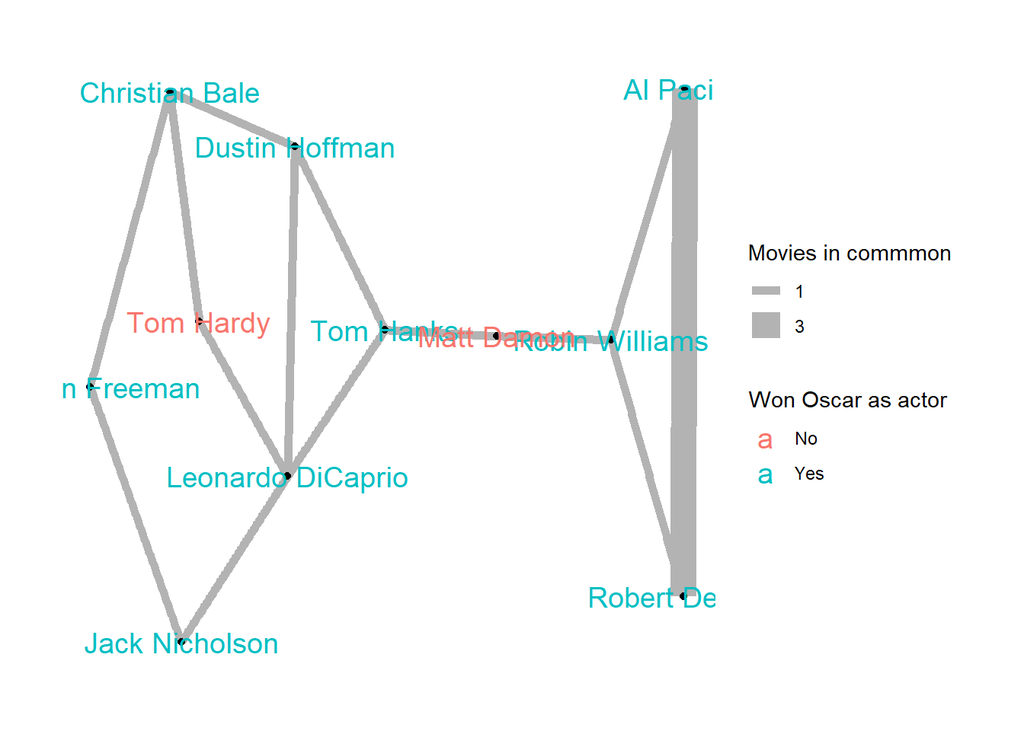

```r
# add labels and populate plot
finalGraph + labs(edge_width="Movies in commmon",
                  color="Won Oscar as actor")
```

# Part 2

Below, the node central measures (eigen_centrality, closeness, betweenness) are computed and summarized in a table:

```r
# compute measures
eigen=eigen_centrality(actors)$vector

close=closeness(actors,normalized=T)

betw=betweenness(actors,normalized=T)
```

```r
# summarize measures in a data frame
DFCentrality=as.data.frame(cbind(eigen,close,betw),stringsAsFactors = F)
names(DFCentrality)=c('Eigenvector','Closeness','Betweenness')

DFCentrality$person=row.names(DFCentrality)
row.names(DFCentrality)=NULL

# populate table head
head(DFCentrality)
```

```
##   Eigenvector Closeness Betweenness            person
## 1  0.60670504 0.3571429  0.37777778    Robin Williams
## 2  0.01469953 0.3703704  0.01111111         Tom Hardy
## 3  0.03468977 0.4545455  0.17777778    Dustin Hoffman
## 4  0.03714365 0.4761905  0.33333333 Leonardo DiCaprio
## 5  0.07209892 0.5000000  0.53333333         Tom Hanks
## 6  1.00000000 0.2702703  0.00000000         Al Pacino
```

#Part 3

A correlation plot with the previous measures is created:

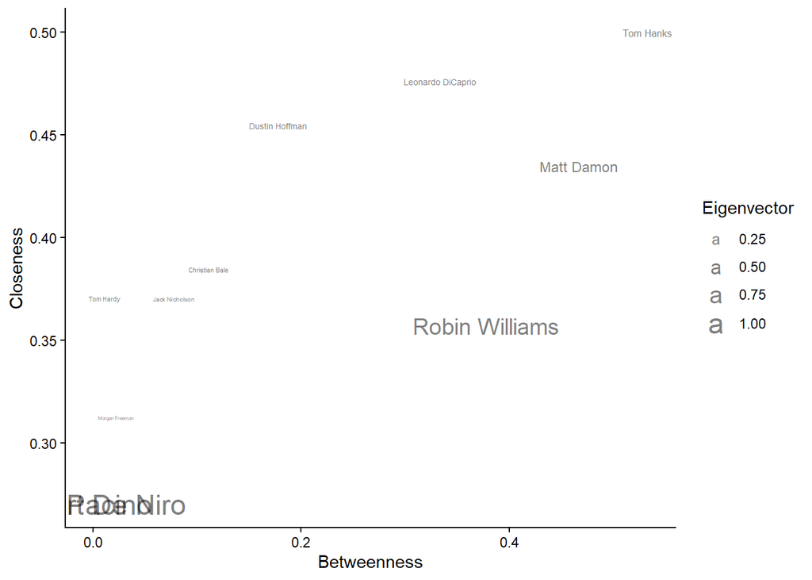

```r
# plot measures and add layers
ggplot(DFCentrality, aes(x=Betweenness, y=Closeness)) +
    theme_classic() +
    geom_text(aes(label=person,size=Eigenvector),show.legend = T,alpha=0.5)
```

**Result**:

Betweenness and closeness appear to have a positive relationship – as the slope between the two increases.

Robin Williams is a notable node with high betweenness and high eigenvector scores, but comparatively low closeness.

# Part 4

Below is the code needed to redo `finalGraph` plot to just show the Hub nodes:

```r
# identify hub nodes
HubNodes=dplyr::slice_max(DFCentrality, order_by = Eigenvector, n = 2)$person
HubNodes
```

```
## [1] "Al Pacino"      "Robert De Niro"
```

```r
# relabel so that plot only shows hub nodes
NodeCount=length(V(actors))

V(actors)$label=''

for (index in seq(1:NodeCount)){
    currentName=V(actors)$name[index]
    if (currentName%in%HubNodes){
            V(actors)$label[index]=currentName
    }
}
```

```r
# create plot
base=ggraph(graph = actors)
```

```
## Using "stress" as default layout
```

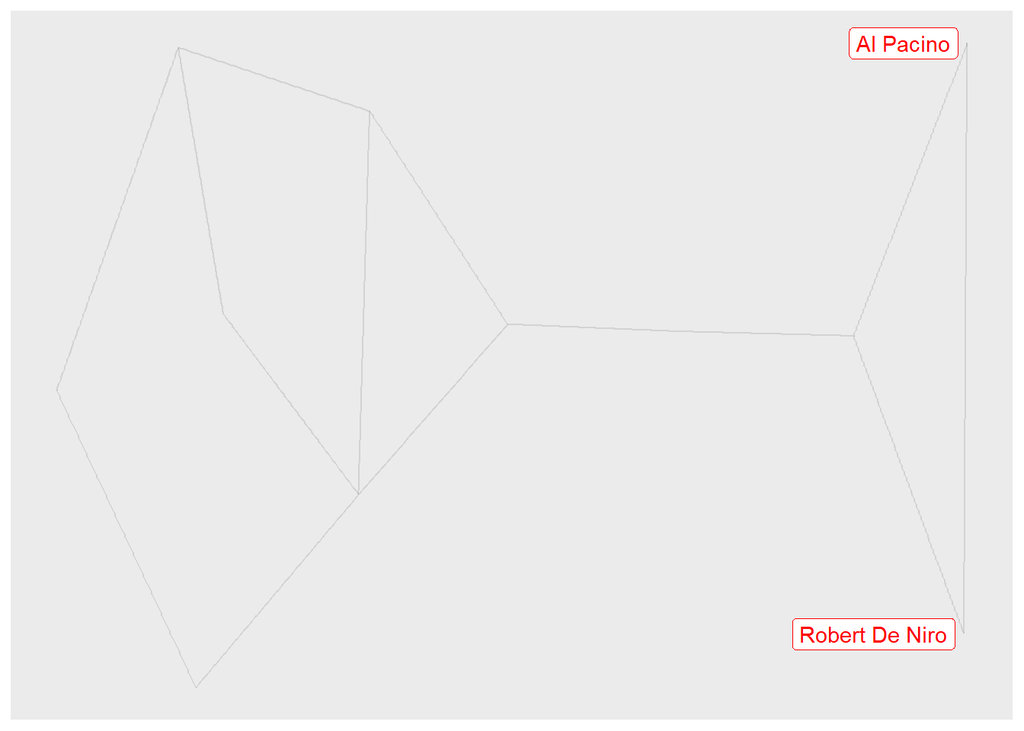

```r
base  + geom_node_label(aes(label = label),
                        repel = TRUE,
                        show.legend = F,
                        color='red') +
         geom_edge_link(alpha=0.1)
```

# Part 5

Below are the computations needed to help determine of communities could be present:

```r
#simulate networks
set.seed(123)
replicates <- 1000

random_transitivities <- replicate(replicates, {
  RandomNet <- rewire(actors,
                      keeping_degseq(niter = gsize(actors) * 10))
  transitivity(RandomNet, type = "global")
})
```

```r
# compute average transativity
mean_random_transitivities=mean(random_transitivities)
```

```r
# compute empirical transativity
empirical_transitivity <- transitivity(actors, type = "global")
```

```r
# summarize computations in a data frame
report_table <- data.frame(
  Metric = c("actors transitivity", "Random-network mean", "Ratio"),
  Value  = round(c(empirical_transitivity,
                    mean_random_transitivities,
                    empirical_transitivity / mean_random_transitivities), 4)
)
```

```r
# populate table
print(report_table)
```

```
##                Metric  Value
## 1 actors transitivity 0.2500
## 2 Random-network mean 0.1310
## 3               Ratio 1.9084
```

**Result**:

The ratio is above 1, so it is possible that communities are present

# Part 6

Since the presence of communities is possible, community detection algorithms are run below (Louvain, walktrap, fast greedy, infomap, Girvan-Newman):

```r
# run community-detection algorithms
algos <- list(
  louvain          =  { set.seed(123); cluster_louvain(actors) },
  walktrap         = cluster_walktrap(actors),
  fast_greedy      = cluster_fast_greedy(actors),
  infomap          = cluster_infomap(actors),
  edge_betweenness = cluster_edge_betweenness(actors)
)
# summarize number of clusters, modularity, and cluster sizes in a data frame
summary_table <- data.frame(
  algorithm   = names(algos),
  n_clusters  = sapply(algos, length),
  modularity_Q  = sapply(algos, modularity),
  cluster_sizes = sapply(algos, function(cl) {
    paste(sort(sizes(cl), decreasing = TRUE), collapse = ", ")
  })
)
```

```r
# summarize computations in a data frame
summary_table <- summary_table[order(-summary_table$modularity_Q), ]
rownames(summary_table) <- NULL

print(summary_table)
```

```
##          algorithm n_clusters modularity_Q cluster_sizes
## 1         walktrap          3    0.4199219       6, 3, 2
## 2          infomap          2    0.4199219          7, 4
## 3 edge_betweenness          2    0.4199219          7, 4
## 4          louvain          3    0.4121094       4, 4, 3
## 5      fast_greedy          3    0.4121094       4, 4, 3
```

**Best Result**: Girvan-Newman tied for best, and since it is a more common algorithm, I’ve chosen to consider it to be the algorithm with the best result.

Below are the codes to plot this best result.

```r
# save each result
for (name in names(algos)) {
  memb <- membership(algos[[name]])
  attr_name <- name
  actors <- set_vertex_attr(actors, attr_name,
                               index = names(memb),
                               value = as.vector(memb))
}
# verify new attributes were added
vertex_attr_names(actors)
```

```
##  [1] "wonOscar"         "color"            "name"             "id"
##  [5] "label"            "louvain"          "walktrap"         "fast_greedy"
##  [9] "infomap"          "edge_betweenness"
```

```r
# plotting best algorithm

base=ggraph(graph =actors) +
          geom_edge_link(alpha=0.2)
```

```
## Using "stress" as default layout
```

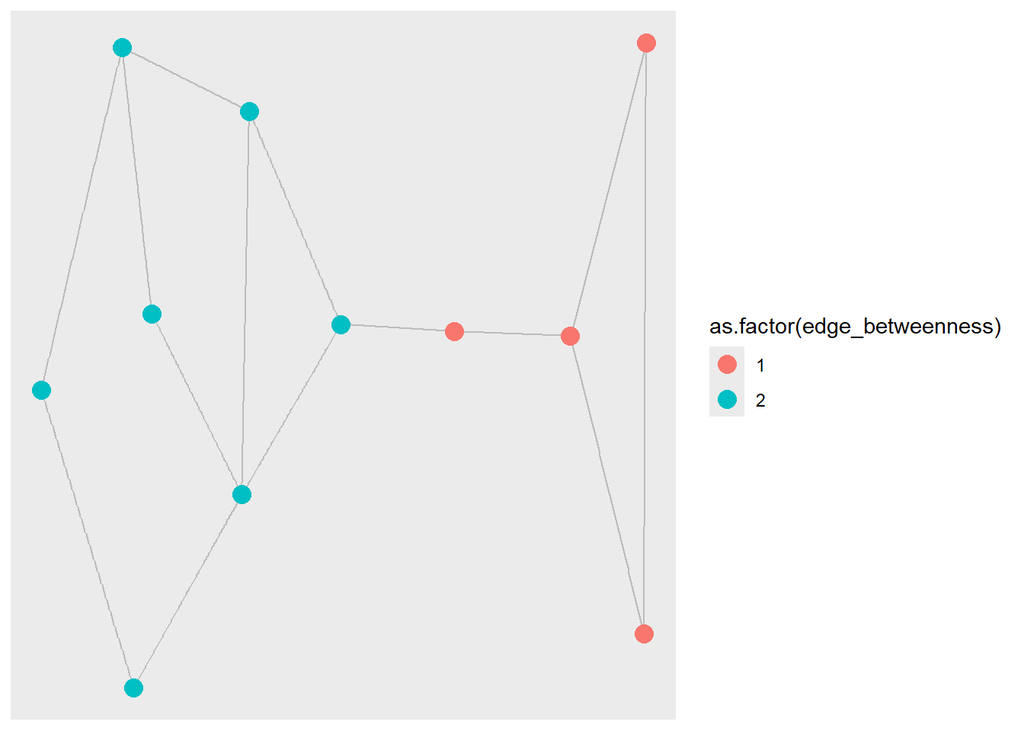

```r
base + geom_node_point(aes(color=as.factor(edge_betweenness)),
                       show.legend = T, size=4)
```